# Прогнозирование оттока клиентов

**Описание проекта**

Оператор связи «Ниединогоразрыва.ком» хочет научиться прогнозировать отток клиентов. Если выяснится, что пользователь планирует уйти, ему будут предложены промокоды и специальные условия. Команда оператора собрала персональные данные о некоторых клиентах, информацию об их тарифах и договорах.

**Описание услуг**

Оператор предоставляет два основных типа услуг:

1. Стационарную телефонную связь. Возможно подключение телефонного аппарата к нескольким линиям одновременно.
2. Интернет. Подключение может быть двух типов: через телефонную линию (DSL, от англ. digital subscriber line, «цифровая абонентская линия») или оптоволоконный кабель (Fiber optic).

Также доступны такие услуги:

1. Интернет-безопасность: антивирус (DeviceProtection) и блокировка небезопасных сайтов (OnlineSecurity);
2. Выделенная линия технической поддержки (TechSupport);
3. Облачное хранилище файлов для резервного копирования данных (OnlineBackup);
4. Стриминговое телевидение (StreamingTV) и каталог фильмов (StreamingMovies).

За услуги клиенты могут платить каждый месяц или заключить договор на 1–2 года. Доступны различные способы расчёта и возможность получения электронного чека.

**Описание данных**

Данные состоят из файлов, полученных из разных источников:

- *contract_new.csv* — информация о договоре;
- *personal_new.csv* — персональные данные клиента;
- *internet_new.csv* — информация об интернет-услугах;
- *phone_new.csv* — информация об услугах телефонии.

Во всех файлах столбец customerID содержит код клиента. Информация о договорах актуальна на 1 февраля 2020.

Признаки:

- *BeginDate* – дата начала пользования услугами,
- *EndDate* – дата окончания пользования услугами,
- *Type* – тип оплаты: ежемесячный, годовой и тд,
- *PaperlessBilling* – безналичный расчет,
- *PaymentMethod* – способ оплаты,
- *MonthlyCharges* – ежемесячные траты на услуги,
- *TotalCharges* – всего потрачено денег на услуги
- *Dependents* – наличие иждивенцев
- *Senior Citizen* – наличие пенсионного статуса по возрасту
- *Partner* – наличие супруга(и)
- *MultipleLines* – наличие возможности ведения параллельных линий во время звонка

**Цель работы** - построение модели прогнозирования оттока клиентов.

**План проекта:**

- [x] Обзор данных;
- [x] Предобработка данных:
  - [x] Переименование столбцов;
  - [x] Изменения типов данных;
  - [x] Объединение данных в общий датафрейм;
  - [x] Обработка пропусков в данных.
- [x] Исследовательский анализ данных:
  - [x] Создание дополнительных признаков;
  - [x] Анализ типов и статусов клиентов;
  - [x] Анализ типа оплаты клиентов;
  - [x] Анализ типа оплаты клиентов;
  - [x] Анализ потраченных средств на услуги по состоянию клинта;
  - [x] Анализ продолжительности пользования услугами по ушедшим и не ушедшим клиентам;
  - [x] Анализ наличие супруги по ушедшим и не ушедшим пользователям;
  - [x] Анализ наличия пенсионного статуса по возрасту у клиентов;
  - [x] Анализ корреляции данных;
  - [x] Анализ дисбаланса классов;
- [x] Подготовка тренировочной и тестовой выборок:
  - [x] Разделение признаков и целевого признака;
  - [x] Масштабирование численных признаков;
  - [x] Кодирование категориальных признаков;
- [x] Обучение моделей;
- [x] Тестирование модели;
- [x] Выводы.

## Обзор данных

```python
!pip install phik
```

```
WARNING: There was an error checking the latest version of pip.
```

```python
from phik import resources, report
import pandas as pd
import seaborn as sns
import numpy as np
import matplotlib.pyplot as plt

from sklearn.model_selection import train_test_split
from sklearn.preprocessing import OneHotEncoder
from sklearn.compose import ColumnTransformer
from sklearn.preprocessing import StandardScaler

from sklearn.pipeline import Pipeline
from sklearn.model_selection import GridSearchCV

from sklearn.tree import DecisionTreeClassifier
from sklearn.ensemble import RandomForestClassifier
from catboost import CatBoostClassifier

from sklearn.metrics import roc_auc_score, roc_curve, auc
```

Создадим константу с датой выгрузки данных:

```python
DATA_LOAD = '2020-02-01'
```

Загрузим исходные данные:

```python
try:
    contract = pd.read_csv('data/contract_new.csv')
    personal = pd.read_csv('data/personal_new.csv')
    internet = pd.read_csv('data/internet_new.csv')
    phone = pd.read_csv('data/phone_new.csv')
except:
    contract = pd.read_csv('/datasets/contract_new.csv')
    personal = pd.read_csv('/datasets/personal_new.csv')
    internet = pd.read_csv('/datasets/internet_new.csv')
    phone = pd.read_csv('/datasets/phone_new.csv')
```

Функция для обзора данных:

```python
def data_viewer(data):

    print("\033[4m")
    print('Случайные 5 строк данных:')
    print("\033[0m")
    display(data.sample(5))

    print("\033[4m")
    print('Describe:')
    print("\033[0m")
    display(data.describe())

    print("\033[4m")
    print('Info:')
    print("\033[0m")
    display(data.info())

    print("\033[4m")
    print('Ошибочные данные:')
    print("\033[0m")
    display(pd.DataFrame(round(data.isna().mean()*100,1)).style.background_gradient('coolwarm'))

    print("\033[4m")
    print('Количество полных дубликатов в данных:')
    print("\033[0m")
    display(data.duplicated().sum())
```

### Обзор данных "информация о договоре"

```python
data_viewer(contract)
```

```
Случайные 5 строк данных:
```

|  | customerID | BeginDate | EndDate | Type | PaperlessBilling | PaymentMethod | MonthlyCharges | TotalCharges |
| --- | --- | --- | --- | --- | --- | --- | --- | --- |
| 3665 | 1545-JFUML | 2014-03-01 | No | Two year | Yes | Electronic check | 99.00 | 7380.45 |
| 4740 | 2778-OCLGR | 2017-10-01 | No | Month-to-month | No | Bank transfer (automatic) | 39.10 | 1094.8 |
| 5291 | 1334-PDUKM | 2014-06-01 | No | One year | No | Credit card (automatic) | 86.45 | 5878.6 |
| 1336 | 3733-LSYCE | 2018-11-01 | No | Month-to-month | No | Bank transfer (automatic) | 75.35 | 1130.25 |
| 2706 | 7598-UAASY | 2019-11-01 | No | Month-to-month | No | Electronic check | 76.40 | 229.2 |

```
Describe:
```

|  | MonthlyCharges |
| --- | --- |
| count | 7043.000000 |
| mean | 64.761692 |
| std | 30.090047 |
| min | 18.250000 |
| 25% | 35.500000 |
| 50% | 70.350000 |
| 75% | 89.850000 |
| max | 118.750000 |

```
Info:

<class 'pandas.core.frame.DataFrame'>
RangeIndex: 7043 entries, 0 to 7042
Data columns (total 8 columns):
 #   Column            Non-Null Count  Dtype
---  ------            --------------  -----
 0   customerID        7043 non-null   object
 1   BeginDate         7043 non-null   object
 2   EndDate           7043 non-null   object
 3   Type              7043 non-null   object
 4   PaperlessBilling  7043 non-null   object
 5   PaymentMethod     7043 non-null   object
 6   MonthlyCharges    7043 non-null   float64
 7   TotalCharges      7043 non-null   object
dtypes: float64(1), object(7)
memory usage: 440.3+ KB
```

```
None
```

```
Ошибочные данные:
```

|  | 0 |
| --- | --- |
| customerID | 0.000000 |
| BeginDate | 0.000000 |
| EndDate | 0.000000 |
| Type | 0.000000 |
| PaperlessBilling | 0.000000 |
| PaymentMethod | 0.000000 |
| MonthlyCharges | 0.000000 |
| TotalCharges | 0.000000 |

```
Количество полных дубликатов в данных:
```

```
0
```

### Обзор данных "персональные данные клиента"

```python
data_viewer(personal)
```

```
Случайные 5 строк данных:
```

|  | customerID | gender | SeniorCitizen | Partner | Dependents |
| --- | --- | --- | --- | --- | --- |
| 2772 | 3470-OBUET | Female | 0 | Yes | Yes |
| 2200 | 6296-DDOOR | Female | 0 | No | No |
| 627 | 6797-UCJHZ | Female | 1 | Yes | No |
| 4086 | 2235-EZAIK | Female | 0 | Yes | No |
| 5472 | 4277-UDIEF | Male | 0 | Yes | Yes |

```
Describe:
```

|  | SeniorCitizen |
| --- | --- |
| count | 7043.000000 |
| mean | 0.162147 |
| std | 0.368612 |
| min | 0.000000 |
| 25% | 0.000000 |
| 50% | 0.000000 |
| 75% | 0.000000 |
| max | 1.000000 |

```
Info:

<class 'pandas.core.frame.DataFrame'>
RangeIndex: 7043 entries, 0 to 7042
Data columns (total 5 columns):
 #   Column         Non-Null Count  Dtype
---  ------         --------------  -----
 0   customerID     7043 non-null   object
 1   gender         7043 non-null   object
 2   SeniorCitizen  7043 non-null   int64
 3   Partner        7043 non-null   object
 4   Dependents     7043 non-null   object
dtypes: int64(1), object(4)
memory usage: 275.2+ KB
```

```
None
```

```
Ошибочные данные:
```

|  | 0 |
| --- | --- |
| customerID | 0.000000 |
| gender | 0.000000 |
| SeniorCitizen | 0.000000 |
| Partner | 0.000000 |
| Dependents | 0.000000 |

```
Количество полных дубликатов в данных:
```

```
0
```

### Обзор данных "информация об интернет-услугах"

```python
data_viewer(internet)
```

```
Случайные 5 строк данных:
```

|  | customerID | InternetService | OnlineSecurity | OnlineBackup | DeviceProtection | TechSupport | StreamingTV | StreamingMovies |
| --- | --- | --- | --- | --- | --- | --- | --- | --- |
| 3319 | 1020-JPQOW | Fiber optic | No | Yes | Yes | Yes | No | No |
| 379 | 1304-BCCFO | DSL | No | No | Yes | No | Yes | Yes |
| 2932 | 1548-ARAGG | DSL | No | Yes | No | Yes | No | No |
| 3157 | 4608-LCIMN | DSL | No | No | No | No | No | No |
| 1875 | 9308-ANMVE | DSL | Yes | Yes | No | No | No | No |

```
Describe:
```

|  | customerID | InternetService | OnlineSecurity | OnlineBackup | DeviceProtection | TechSupport | StreamingTV | StreamingMovies |
| --- | --- | --- | --- | --- | --- | --- | --- | --- |
| count | 5517 | 5517 | 5517 | 5517 | 5517 | 5517 | 5517 | 5517 |
| unique | 5517 | 2 | 2 | 2 | 2 | 2 | 2 | 2 |
| top | 7590-VHVEG | Fiber optic | No | No | No | No | No | No |
| freq | 1 | 3096 | 3498 | 3088 | 3095 | 3473 | 2810 | 2785 |

```
Info:

<class 'pandas.core.frame.DataFrame'>
RangeIndex: 5517 entries, 0 to 5516
Data columns (total 8 columns):
 #   Column            Non-Null Count  Dtype
---  ------            --------------  -----
 0   customerID        5517 non-null   object
 1   InternetService   5517 non-null   object
 2   OnlineSecurity    5517 non-null   object
 3   OnlineBackup      5517 non-null   object
 4   DeviceProtection  5517 non-null   object
 5   TechSupport       5517 non-null   object
 6   StreamingTV       5517 non-null   object
 7   StreamingMovies   5517 non-null   object
dtypes: object(8)
memory usage: 344.9+ KB
```

```
None
```

```
Ошибочные данные:
```

|  | 0 |
| --- | --- |
| customerID | 0.000000 |
| InternetService | 0.000000 |
| OnlineSecurity | 0.000000 |
| OnlineBackup | 0.000000 |
| DeviceProtection | 0.000000 |
| TechSupport | 0.000000 |
| StreamingTV | 0.000000 |
| StreamingMovies | 0.000000 |

```
Количество полных дубликатов в данных:
```

```
0
```

### Обзор данных "информация об услугах телефонии"

```python
data_viewer(phone)
```

```
Случайные 5 строк данных:
```

|  | customerID | MultipleLines |
| --- | --- | --- |
| 1064 | 1641-RQDAY | Yes |
| 120 | 7850-VWJUU | No |
| 402 | 5760-WRAHC | No |
| 6146 | 8071-SBTRN | Yes |
| 6154 | 2030-BTZRO | No |

```
Describe:
```

|  | customerID | MultipleLines |
| --- | --- | --- |
| count | 6361 | 6361 |
| unique | 6361 | 2 |
| top | 5575-GNVDE | No |
| freq | 1 | 3390 |

```
Info:

<class 'pandas.core.frame.DataFrame'>
RangeIndex: 6361 entries, 0 to 6360
Data columns (total 2 columns):
 #   Column         Non-Null Count  Dtype
---  ------         --------------  -----
 0   customerID     6361 non-null   object
 1   MultipleLines  6361 non-null   object
dtypes: object(2)
memory usage: 99.5+ KB
```

```
None
```

```
Ошибочные данные:
```

|  | 0 |
| --- | --- |
| customerID | 0.000000 |
| MultipleLines | 0.000000 |

```
Количество полных дубликатов в данных:
```

```
0
```

### Выводы

Проведя обзор данных отметим особенности в датафреймах:

- Пропуски и полные дубликаты в датафреймах отсутствуют;
- При проведении предобработки следует переименовать столбцы и изменить тип данных в датафреймах;

## Предобработка данных

### Переименование столбцов

```python
contract = (contract.rename(
    columns={
        'customerID': 'customer_id',
        'BeginDate': 'begin_date',
        'EndDate': 'end_date',
        'Type': 'type',
        'PaperlessBilling': 'paperless_billing',
        'PaymentMethod': 'payment_method',
        'MonthlyCharges': 'monthly_charges',
        'TotalCharges': 'total_charges'
    })
)
```

```python
personal = (personal.rename(
    columns={
        'customerID': 'customer_id',
        'SeniorCitizen': 'senior_citizen',
        'Partner': 'partner',
        'Dependents': 'dependents'
    })
)
```

```python
internet = (internet.rename(
    columns={
        'customerID': 'customer_id',
        'InternetService': 'internet_service',
        'OnlineSecurity': 'online_security',
        'OnlineBackup': 'online_backup',
        'DeviceProtection': 'device_protection',
        'TechSupport': 'tech_support',
        'StreamingTV': 'streaming_tv',
        'StreamingMovies': 'streaming_movies'
    })
)
```

```python
phone = (phone.rename(
    columns={
        'customerID': 'customer_id',
        'MultipleLines': 'multiple_lines'
    })
)
```

### Изменения типов данных

```python
contract['begin_date'] = pd.to_datetime(contract['begin_date'])
```

Проверим ушли какие-либо клиенты в дату выгрузки данных:

```python
(contract['end_date'] == DATA_LOAD).sum()
```

```
0
```

Таких клиентов нет. Теперь мы смело можем прировнять дату выгрузки для клиетов не ушедших:

```python
contract.loc[contract['end_date'] == 'No', 'end_date'] = DATA_LOAD
```

```python
contract['end_date'] = pd.to_datetime(contract['end_date'])
```

```python
pd.to_datetime(DATA_LOAD) - contract['end_date'].max()
```

```
Timedelta('0 days 00:00:00')
```

```python
contract['total_charges'] = pd.to_numeric(contract['total_charges'], errors='coerce')
```

```python
contract.info()
```

```
<class 'pandas.core.frame.DataFrame'>
RangeIndex: 7043 entries, 0 to 7042
Data columns (total 8 columns):
 #   Column             Non-Null Count  Dtype
---  ------             --------------  -----
 0   customer_id        7043 non-null   object
 1   begin_date         7043 non-null   datetime64[ns]
 2   end_date           7043 non-null   datetime64[ns]
 3   type               7043 non-null   object
 4   paperless_billing  7043 non-null   object
 5   payment_method     7043 non-null   object
 6   monthly_charges    7043 non-null   float64
 7   total_charges      7032 non-null   float64
dtypes: datetime64[ns](2), float64(2), object(4)
memory usage: 440.3+ KB
```

Столбец *total_charges* содержит пропуски. Посмотрим откуда они могли появится.

```python
contract[contract['total_charges'].isna()]
```

|  | customer_id | begin_date | end_date | type | paperless_billing | payment_method | monthly_charges | total_charges |
| --- | --- | --- | --- | --- | --- | --- | --- | --- |
| 488 | 4472-LVYGI | 2020-02-01 | 2020-02-01 | Two year | Yes | Bank transfer (automatic) | 52.55 | NaN |
| 753 | 3115-CZMZD | 2020-02-01 | 2020-02-01 | Two year | No | Mailed check | 20.25 | NaN |
| 936 | 5709-LVOEQ | 2020-02-01 | 2020-02-01 | Two year | No | Mailed check | 80.85 | NaN |
| 1082 | 4367-NUYAO | 2020-02-01 | 2020-02-01 | Two year | No | Mailed check | 25.75 | NaN |
| 1340 | 1371-DWPAZ | 2020-02-01 | 2020-02-01 | Two year | No | Credit card (automatic) | 56.05 | NaN |
| 3331 | 7644-OMVMY | 2020-02-01 | 2020-02-01 | Two year | No | Mailed check | 19.85 | NaN |
| 3826 | 3213-VVOLG | 2020-02-01 | 2020-02-01 | Two year | No | Mailed check | 25.35 | NaN |
| 4380 | 2520-SGTTA | 2020-02-01 | 2020-02-01 | Two year | No | Mailed check | 20.00 | NaN |
| 5218 | 2923-ARZLG | 2020-02-01 | 2020-02-01 | One year | Yes | Mailed check | 19.70 | NaN |
| 6670 | 4075-WKNIU | 2020-02-01 | 2020-02-01 | Two year | No | Mailed check | 73.35 | NaN |
| 6754 | 2775-SEFEE | 2020-02-01 | 2020-02-01 | Two year | Yes | Bank transfer (automatic) | 61.90 | NaN |

```python
#contract = contract[~contract['total_charges'].isna()]
```

```python
#Заполним пропуски в столбце total_charges значениями столбца monthly_charges:
value_monthly_charges = contract.loc[contract['total_charges'].isna(), 'monthly_charges']
contract['total_charges'] = contract['monthly_charges'].fillna(value=value_monthly_charges)
```

**✔️ Комментарий ревьювера v2:** Хорошо, что обратил внимание на пустые строки в признаке total_charges! Как рекомендация, можно также заменить месячными значениями платежей

### Объединение данных в общий датафрейм

Перед объединением данных убедимся в отсутсвие дубликатов в столбце *customer_id*:

```python
contract['customer_id'].duplicated().sum()
```

```
0
```

```python
personal['customer_id'].duplicated().sum()
```

```
0
```

```python
internet['customer_id'].duplicated().sum()
```

```
0
```

```python
phone['customer_id'].duplicated().sum()
```

```
0
```

Приведем к общему виду значения столбца *senior_citizen* таблцицы *personal*:

```python
personal.loc[personal['senior_citizen'] == 1, 'senior_citizen'] = 'Yes'
personal.loc[personal['senior_citizen'] == 0, 'senior_citizen'] = 'No'
```

Проверим результат:

```python
personal['senior_citizen'].unique()
```

```
array(['No', 'Yes'], dtype=object)
```

Объединим таблицы по столбцу *customer_id*:

```python
total_table = contract.merge(personal, on='customer_id', how='left')
```

```python
total_table = total_table.merge(internet, on='customer_id', how='left')
```

```python
total_table = total_table.merge(phone, on='customer_id', how='left')
```

```python
total_table.head()
```

|  | customer_id | begin_date | end_date | type | paperless_billing | payment_method | monthly_charges | total_charges | gender | senior_citizen | partner | dependents | internet_service | online_security | online_backup | device_protection | tech_support | streaming_tv | streaming_movies | multiple_lines |
| --- | --- | --- | --- | --- | --- | --- | --- | --- | --- | --- | --- | --- | --- | --- | --- | --- | --- | --- | --- | --- |
| 0 | 7590-VHVEG | 2020-01-01 | 2020-02-01 | Month-to-month | Yes | Electronic check | 29.85 | 29.85 | Female | No | Yes | No | DSL | No | Yes | No | No | No | No | NaN |
| 1 | 5575-GNVDE | 2017-04-01 | 2020-02-01 | One year | No | Mailed check | 56.95 | 56.95 | Male | No | No | No | DSL | Yes | No | Yes | No | No | No | No |
| 2 | 3668-QPYBK | 2019-10-01 | 2020-02-01 | Month-to-month | Yes | Mailed check | 53.85 | 53.85 | Male | No | No | No | DSL | Yes | Yes | No | No | No | No | No |
| 3 | 7795-CFOCW | 2016-05-01 | 2020-02-01 | One year | No | Bank transfer (automatic) | 42.30 | 42.30 | Male | No | No | No | DSL | Yes | No | Yes | Yes | No | No | NaN |
| 4 | 9237-HQITU | 2019-09-01 | 2020-02-01 | Month-to-month | Yes | Electronic check | 70.70 | 70.70 | Female | No | No | No | Fiber optic | No | No | No | No | No | No | No |

```python
total_table.info()
```

```
<class 'pandas.core.frame.DataFrame'>
Int64Index: 7043 entries, 0 to 7042
Data columns (total 20 columns):
 #   Column             Non-Null Count  Dtype
---  ------             --------------  -----
 0   customer_id        7043 non-null   object
 1   begin_date         7043 non-null   datetime64[ns]
 2   end_date           7043 non-null   datetime64[ns]
 3   type               7043 non-null   object
 4   paperless_billing  7043 non-null   object
 5   payment_method     7043 non-null   object
 6   monthly_charges    7043 non-null   float64
 7   total_charges      7043 non-null   float64
 8   gender             7043 non-null   object
 9   senior_citizen     7043 non-null   object
 10  partner            7043 non-null   object
 11  dependents         7043 non-null   object
 12  internet_service   5517 non-null   object
 13  online_security    5517 non-null   object
 14  online_backup      5517 non-null   object
 15  device_protection  5517 non-null   object
 16  tech_support       5517 non-null   object
 17  streaming_tv       5517 non-null   object
 18  streaming_movies   5517 non-null   object
 19  multiple_lines     6361 non-null   object
dtypes: datetime64[ns](2), float64(2), object(16)
memory usage: 1.1+ MB
```

Обработаем пропуски после объединения таблиц:

```python
total_table['internet_service'] = total_table['internet_service'].fillna(value='No internet')
```

```python
total_table['online_security'] = total_table['online_security'].fillna(value='No')
```

```python
total_table['online_backup'] = total_table['online_backup'].fillna(value='No')
```

```python
total_table['device_protection'] = total_table['device_protection'].fillna(value='No')
```

```python
total_table['tech_support'] = total_table['tech_support'].fillna(value='No')
```

```python
total_table['streaming_tv'] = total_table['streaming_tv'].fillna(value='No')
```

```python
total_table['streaming_movies'] = total_table['streaming_movies'].fillna(value='No')
```

```python
total_table['multiple_lines'] = total_table['multiple_lines'].fillna(value='No phone')
```

Убедимся в отсутствие пропусков:

```python
total_table.info()
```

```
<class 'pandas.core.frame.DataFrame'>
Int64Index: 7043 entries, 0 to 7042
Data columns (total 20 columns):
 #   Column             Non-Null Count  Dtype
---  ------             --------------  -----
 0   customer_id        7043 non-null   object
 1   begin_date         7043 non-null   datetime64[ns]
 2   end_date           7043 non-null   datetime64[ns]
 3   type               7043 non-null   object
 4   paperless_billing  7043 non-null   object
 5   payment_method     7043 non-null   object
 6   monthly_charges    7043 non-null   float64
 7   total_charges      7043 non-null   float64
 8   gender             7043 non-null   object
 9   senior_citizen     7043 non-null   object
 10  partner            7043 non-null   object
 11  dependents         7043 non-null   object
 12  internet_service   7043 non-null   object
 13  online_security    7043 non-null   object
 14  online_backup      7043 non-null   object
 15  device_protection  7043 non-null   object
 16  tech_support       7043 non-null   object
 17  streaming_tv       7043 non-null   object
 18  streaming_movies   7043 non-null   object
 19  multiple_lines     7043 non-null   object
dtypes: datetime64[ns](2), float64(2), object(16)
memory usage: 1.1+ MB
```

## Исследовательский анализ

### Создание дополнительных признаков

```python
total_table['lost_user'] = total_table['end_date'].apply(
    lambda x: 0 if x == pd.to_datetime(DATA_LOAD) else 1)
```

```python
total_table['lost_user'].unique()
```

```
array([0, 1], dtype=int64)
```

Создадим столбец содержащий продолжительность пользования услугами клиентов:

```python
total_table['duration'] = (total_table['end_date'] - total_table['begin_date']).apply(lambda x: x.days)
```

Создадим столбец содержащий количество услуг используемых клиентами:

```python
total_table['number_of_services'] = (
    ~(total_table['internet_service']=='No internet') * 1 +
    (total_table['online_security']=='Yes') +
    (total_table['online_backup']=='Yes') +
    (total_table['device_protection']=='Yes') +
    (total_table['tech_support']=='Yes') +
    (total_table['streaming_tv']=='Yes') +
    (total_table['streaming_movies']=='Yes') +
    (total_table['streaming_movies']=='Yes')
)
```

Разделим клиентов на типы по продолжительности использования услуг:

- *newcomer* - новичок (пользуются услугами не больше года);
- *constant* - постоянный (пользуются услугами более года).

```python
total_table['type_user'] = total_table['duration'].apply(
    lambda x: 'newcomer' if x < 366 else 'constant')
```

Каждому клиенту сопоставим статус, определяемый по количеству используемых услуг:

- *ordinary* - обычный (использует до 3 услуг включительно);
- *premium* - премиум (использует от 4 услуг).

```python
total_table['status_user'] = total_table['number_of_services'].apply(
    lambda x: 'ordinary' if x < 4 else 'premium')
```

### Анализ типов и статусов клиентов

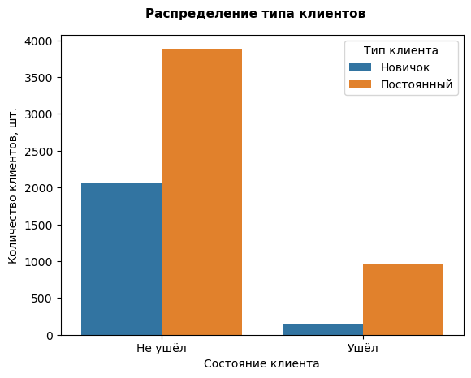

```python
fig = plt.figure()
ax = fig.add_subplot()

fig.suptitle('Распределение типа клиентов', fontsize=11, fontweight='bold', y=0.95)

sns.countplot(x='lost_user', hue='type_user', data=total_table)

ax.set(xlabel='Состояние клиента', ylabel='Количество клиентов, шт.')
ax.legend(['Новичок', 'Постоянный'], title="Тип клиента")

plt.xticks([0, 1], ['Не ушёл', 'Ушёл'])
plt.show();
```

Из графика видно, что постоянные клиенты, продолжительность оказания услуг которым более 365 дней, преобладают в компании. Также стоит отметить, что чаще компанию покидают тоже постоянные клиенты.

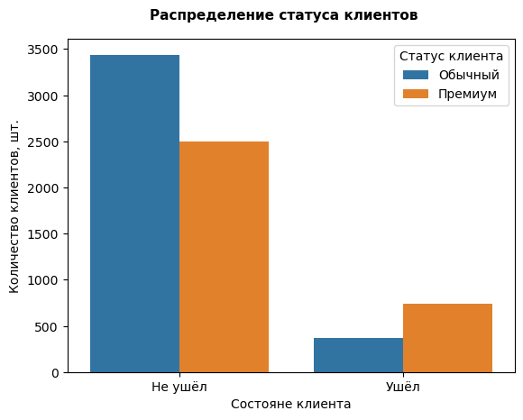

```python
fig = plt.figure()
ax = fig.add_subplot()

fig.suptitle('Распределение статуса клиентов', fontsize=11, fontweight='bold', y=0.95)

sns.countplot(x='lost_user', hue='status_user', data=total_table)

ax.set(xlabel='Состояне клиента', ylabel='Количество клиентов, шт.')
ax.legend(['Обычный', 'Премиум'], title="Статус клиента")

plt.xticks([0, 1], ['Не ушёл', 'Ушёл'])
plt.show();
```

Проанализировав график, можно заметить, что в компании преобладают обычные клиенты, количество используемых услуг которых ограничивается 3. Стоит отметить, что компанию чаще покидают клиенты премиум, которые используют более 3 услуг.

### Анализ типа оплаты клиентов

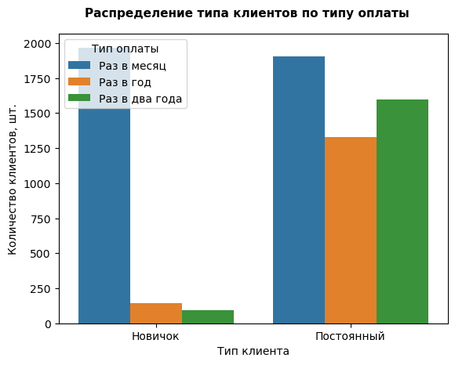

```python
fig = plt.figure()
ax = fig.add_subplot()

fig.suptitle('Распределение типа клиентов по типу оплаты', fontsize=11, fontweight='bold', y=0.95)

sns.countplot(x='type_user', hue='type', data=total_table, hue_order=['Month-to-month', 'One year', 'Two year']);

ax.set(xlabel='Тип клиента', ylabel='Количество клиентов, шт.')
ax.legend(['Раз в месяц', 'Раз в год', 'Раз в два года'], title="Тип оплаты")

plt.xticks([0, 1], ['Новичок', 'Постоянный'])
plt.show();
```

Из графика можно сделать вывод, что клиенты-новички намного чаще используют ежемесячную оплату. Типы оплат постоянных клиентов более сбалансированы между собой.

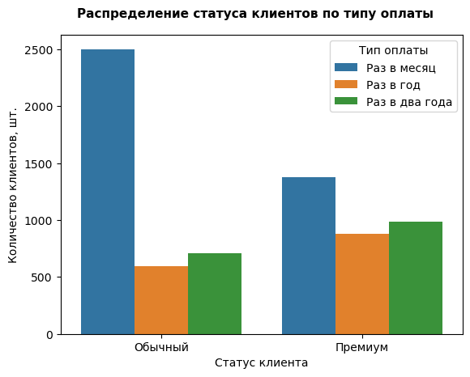

```python
fig = plt.figure()
ax = fig.add_subplot()

fig.suptitle('Распределение статуса клиентов по типу оплаты', fontsize=11, fontweight='bold', y=0.95)

sns.countplot(x='status_user', hue='type', data=total_table, hue_order=['Month-to-month', 'One year', 'Two year']);

ax.set(xlabel='Статус клиента', ylabel='Количество клиентов, шт.')
ax.legend(['Раз в месяц', 'Раз в год', 'Раз в два года'], title="Тип оплаты")

plt.xticks([0, 1], ['Обычный', 'Премиум'])
plt.show();
```

Из графика можно сделать вывод, что обычные клиенты предпочитаю ежемесячную оплату. У клиентов премиум тип оплаты более сбалансирован.

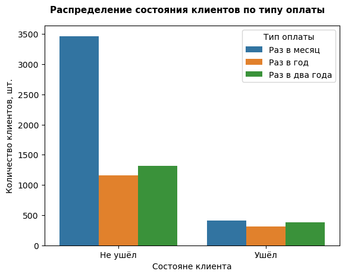

```python
fig = plt.figure()
ax = fig.add_subplot()

fig.suptitle('Распределение состояния клиентов по типу оплаты', fontsize=11, fontweight='bold', y=0.95)


sns.countplot(x='lost_user', hue='type', data=total_table, hue_order=['Month-to-month', 'One year', 'Two year']);

ax.set(xlabel='Состояне клиента', ylabel='Количество клиентов, шт.')
ax.legend(['Раз в месяц', 'Раз в год', 'Раз в два года'], title="Тип оплаты")

plt.xticks([0, 1], ['Не ушёл', 'Ушёл'])
plt.show();
```

У ушедших клиентов типы оплат сбалансированы. Что свидетельствует, о не влияние типа оплаты на решение отказаться от услуг.

### Анализ потраченных средств на услуги по состоянию клинта

Найдем *min* и *max* для столбцов *total_charges* и *monthly_charges* и убедимся что значения лежат в приемлемых диапазонах.

```python
total_table['total_charges'].min()
```

```
18.25
```

```python
total_table['total_charges'].max()
```

```
118.75
```

```python
total_table['monthly_charges'].min()
```

```
18.25
```

```python
total_table['monthly_charges'].max()
```

```
118.75
```

Построим распределение всех потраченных средств на оплату услуг для каждого типа клиента:

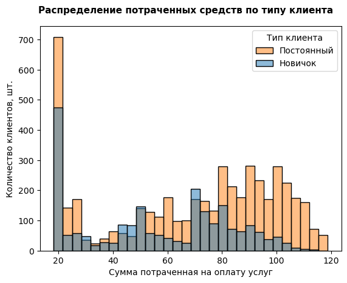

```python
fig = plt.figure()
ax = fig.add_subplot()

fig.suptitle('Распределение потраченных средств по типу клиента',
             fontsize=11, fontweight='bold', y=0.95)


sns.histplot(data=total_table, x='total_charges', hue='type_user', bins=30);

ax.set(xlabel='Сумма потраченная на оплату услуг', ylabel='Количество клиентов, шт.')
ax.legend(['Постоянный', 'Новичок'], title="Тип клиента")


plt.show();
```

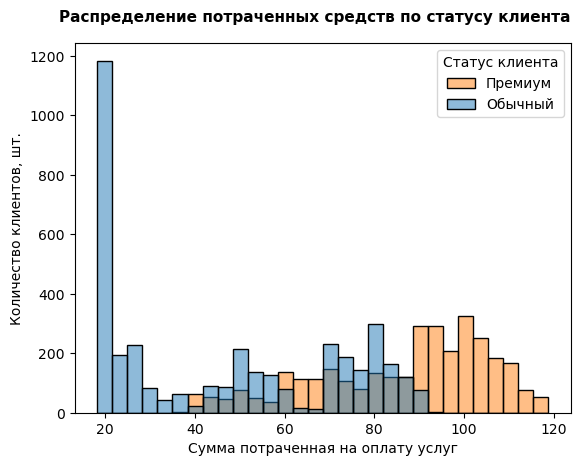

```python
fig = plt.figure()
ax = fig.add_subplot()

fig.suptitle('Распределение потраченных средств по статусу клиента',
             fontsize=11, fontweight='bold', y=0.95)


sns.histplot(data=total_table, x='total_charges', hue='status_user', bins=30);

ax.set(xlabel='Сумма потраченная на оплату услуг', ylabel='Количество клиентов, шт.')
ax.legend(['Премиум', 'Обычный'], title="Статус клиента")


plt.show();
```

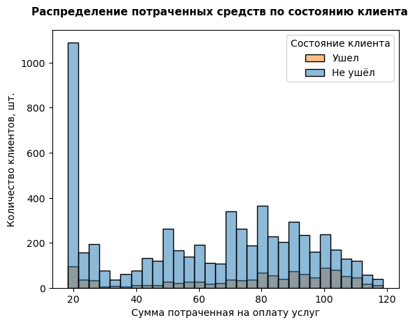

```python
fig = plt.figure()
ax = fig.add_subplot()

fig.suptitle('Распределение потраченных средств по состоянию клиента',
             fontsize=11, fontweight='bold', y=0.95)


sns.histplot(data=total_table, x='total_charges', hue='lost_user', bins=30);

ax.set(xlabel='Сумма потраченная на оплату услуг', ylabel='Количество клиентов, шт.')
ax.legend(['Ушел', 'Не ушёл'], title="Состояние клиента")


plt.show();
```

Построим "ящик с усами" для столбца *total_charges*:

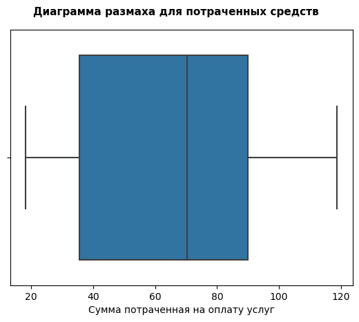

```python
fig = plt.figure()
ax = fig.add_subplot()

fig.suptitle('Диаграмма размаха для потраченных средств',
             fontsize=11, fontweight='bold', y=0.95)


sns.boxplot(data=total_table, x='total_charges');

ax.set(xlabel='Сумма потраченная на оплату услуг')

plt.show();
```

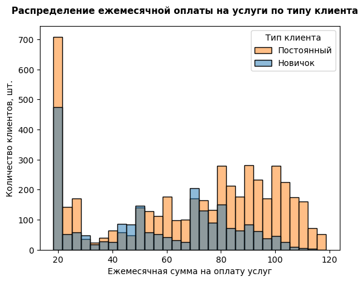

```python
fig = plt.figure()
ax = fig.add_subplot()

fig.suptitle('Распределение ежемесячной оплаты на услуги по типу клиента',
             fontsize=11, fontweight='bold', y=0.95)


sns.histplot(data=total_table, x='monthly_charges', hue='type_user', bins=30);

ax.set(xlabel='Ежемесячная сумма на оплату услуг', ylabel='Количество клиентов, шт.')
ax.legend(['Постоянный', 'Новичок'], title="Тип клиента")


plt.show();
```

Анализируя график заметим, что в среднем постоянные клиенты ежемесячно платят больше, чем клиенты новички.

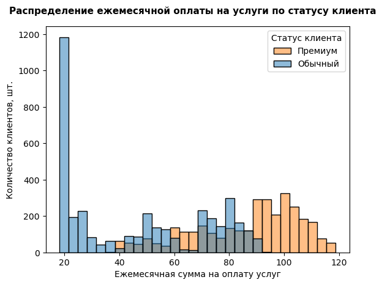

```python
fig = plt.figure()
ax = fig.add_subplot()

fig.suptitle('Распределение ежемесячной оплаты на услуги по статусу клиента',
             fontsize=11, fontweight='bold', y=0.95)


sns.histplot(data=total_table, x='monthly_charges', hue='status_user', bins=30);

ax.set(xlabel='Ежемесячная сумма на оплату услуг', ylabel='Количество клиентов, шт.')
ax.legend(['Премиум', 'Обычный'], title="Статус клиента")


plt.show();
```

По данному графику заметим, что клиенты со статусом премиум в среднем платят ежемесячно больше, чем обычные клиенты.

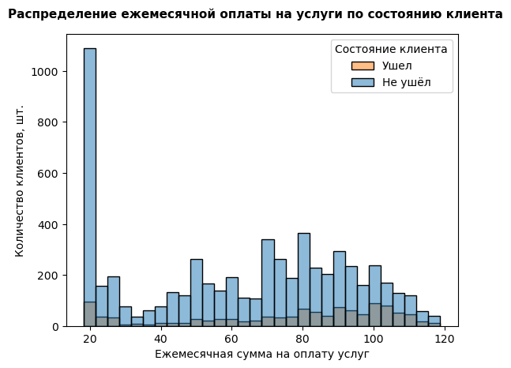

```python
fig = plt.figure()
ax = fig.add_subplot()

fig.suptitle('Распределение ежемесячной оплаты на услуги по состоянию клиента',
             fontsize=11, fontweight='bold', y=0.95)


sns.histplot(data=total_table, x='monthly_charges', hue='lost_user', bins=30);

ax.set(xlabel='Ежемесячная сумма на оплату услуг', ylabel='Количество клиентов, шт.')
ax.legend(['Ушел', 'Не ушёл'], title="Состояние клиента")


plt.show();
```

Распределения ежемесячной оплаты для отказавшихся и не отказавшихся от услуг клиентов сопоставимы.

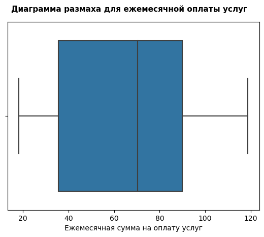

```python
fig = plt.figure()
ax = fig.add_subplot()

fig.suptitle('Диаграмма размаха для ежемесячной оплаты услуг',
             fontsize=11, fontweight='bold', y=0.95)


sns.boxplot(data=total_table, x='monthly_charges');

ax.set(xlabel='Ежемесячная сумма на оплату услуг')

plt.show();
```

Проанализировав диаграмму размаха для для ежемесячной оплаты услуг клиентами, отметим, датасет скошен влево.

### Анализ продолжительности пользования услугами по ушедшим и не ушедшим клиентам

Найдем *min* и *max* для столбца *duration* и убедимся что значения лежат в приемлемом диапазоне.

```python
total_table['duration'].min()
```

```
0
```

```python
total_table['duration'].max()
```

```
2314
```

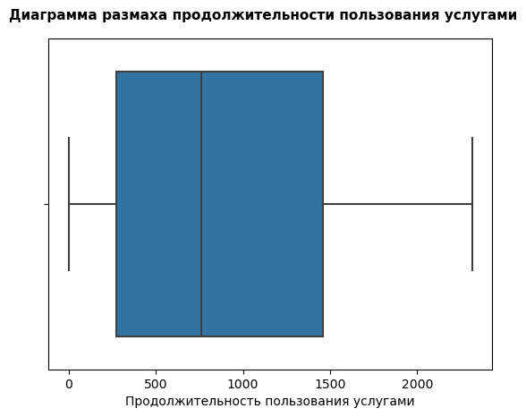

```python
fig = plt.figure()
ax = fig.add_subplot()

fig.suptitle('Диаграмма размаха продолжительности пользования услугами',
             fontsize=11, fontweight='bold', y=0.95)


sns.boxplot(data=total_table, x='duration');

ax.set(xlabel='Продолжительность пользования услугами')

plt.show();
```

Проанализировав диаграмму размаха продолжительности пользования услугами, отметим, датасет скошен вправо.

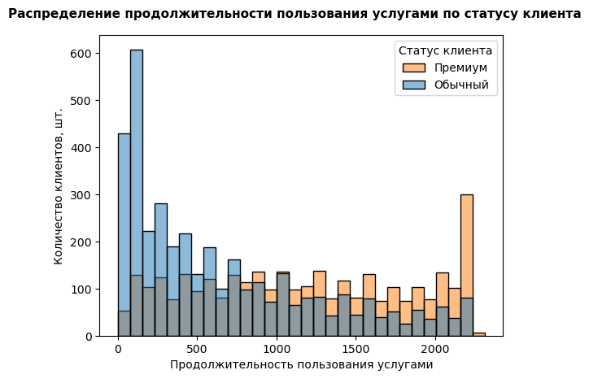

```python
fig = plt.figure()
ax = fig.add_subplot()

fig.suptitle('Распределение продолжительности пользования услугами по статусу клиента',
             fontsize=11, fontweight='bold', y=0.95)


sns.histplot(data=total_table, x='duration', hue='status_user', bins=30);

ax.set(xlabel='Продолжительность пользования услугами', ylabel='Количество клиентов, шт.')
ax.legend(['Премиум', 'Обычный'], title="Статус клиента")


plt.show();
```

Проанализировав график заметим, что премиум клиенты равномерно распределены по продолжительности пользования услугами. Что касается обычных клиентов, то со временем их становится меньше. Это может быть обусловлено с получением ими статуса премиум или отказом от услуг компании.

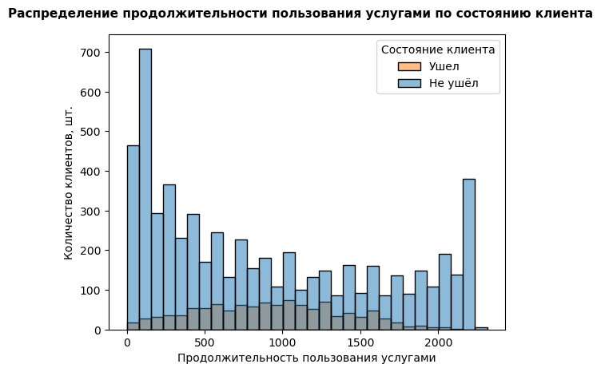

```python
fig = plt.figure()
ax = fig.add_subplot()

fig.suptitle('Распределение продолжительности пользования услугами по состоянию клиента',
             fontsize=11, fontweight='bold', y=0.95)


sns.histplot(data=total_table, x='duration', hue='lost_user', bins=30);

ax.set(xlabel='Продолжительность пользования услугами', ylabel='Количество клиентов, шт.')
ax.legend(['Ушел', 'Не ушёл'], title="Состояние клиента")


plt.show();
```

Проанализирова график заметим, что среднее значение продолжительности пользования услугами клиентов которые решили отказаться, составляет 1000 дней.

### Анализ наличие супруги по ушедшим и не ушедшим пользователям

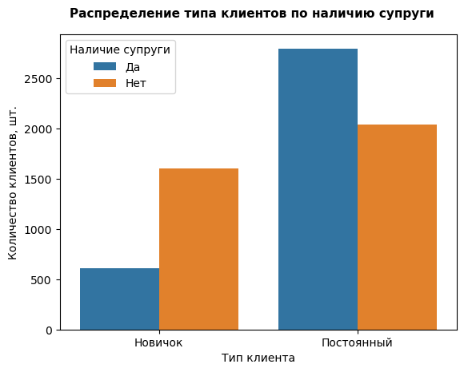

```python
fig = plt.figure()
ax = fig.add_subplot()

fig.suptitle('Распределение типа клиентов по наличию супруги', fontsize=11, fontweight='bold', y=0.95)

sns.countplot(x='type_user', hue='partner', data=total_table, hue_order=['Yes', 'No']);

ax.set(xlabel='Тип клиента', ylabel='Количество клиентов, шт.')
ax.legend(['Да', 'Нет'], title="Наличие супруги")

plt.xticks([0, 1], ['Новичок', 'Постоянный'])
plt.show();
```

Проанализировав график отметим, что большинство клиентов новичков не имеют супругу. Постоянные клиенты в большинстве своем имеют супругу.

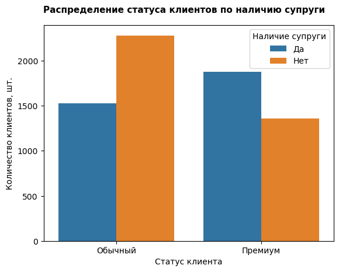

```python
fig = plt.figure()
ax = fig.add_subplot()

fig.suptitle('Распределение статуса клиентов по наличию супруги', fontsize=11, fontweight='bold', y=0.95)

sns.countplot(x='status_user', hue='partner', data=total_table, hue_order=['Yes', 'No']);

ax.set(xlabel='Статус клиента', ylabel='Количество клиентов, шт.')
ax.legend(['Да', 'Нет'], title="Наличие супруги")

plt.xticks([0, 1], ['Обычный', 'Премиум'])
plt.show();
```

Обычные клиенты в большинстве своем не имеют супругу, а вот клиенты пермиум на оборот в большинстве имеют супругу.

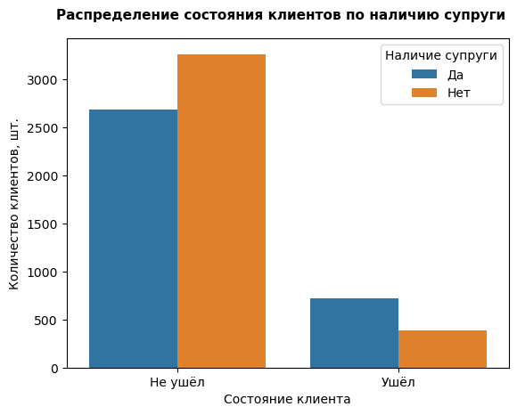

```python
fig = plt.figure()
ax = fig.add_subplot()

fig.suptitle('Распределение состояния клиентов по наличию супруги', fontsize=11, fontweight='bold', y=0.95)

sns.countplot(x='lost_user', hue='partner', data=total_table, hue_order=['Yes', 'No']);

ax.set(xlabel='Состояние клиента', ylabel='Количество клиентов, шт.')
ax.legend(['Да', 'Нет'], title="Наличие супруги")

plt.xticks([0, 1], ['Не ушёл', 'Ушёл'])
plt.show();
```

В большинстве своем клиенты не отказывающиеся от услуг компании не имеют супругу. А вот клиенты решившие отказаться от услуг в большинстве своем имеют супругу.

### Анализ наличия пенсионного статуса по возрасту у клиентов

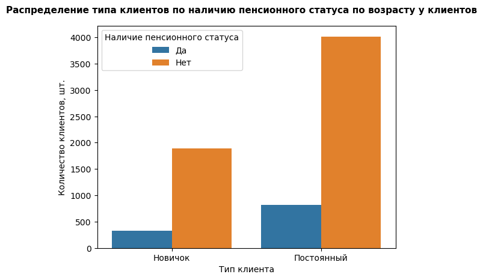

```python
fig = plt.figure()
ax = fig.add_subplot()

fig.suptitle('Распределение типа клиентов по наличию пенсионного статуса по возрасту у клиентов',
             fontsize=11, fontweight='bold', y=0.95)

sns.countplot(x='type_user', hue='senior_citizen', data=total_table, hue_order=['Yes', 'No']);

ax.set(xlabel='Тип клиента', ylabel='Количество клиентов, шт.')
ax.legend(['Да', 'Нет'], title="Наличие пенсионного статуса")

plt.xticks([0, 1], ['Новичок', 'Постоянный'])
plt.show();
```

Распределения клиентов новичков и постоянных по наличиют пенсионного статуса сопоставимы. В большинстве своем клиенты не обладают пенсионным статусом.

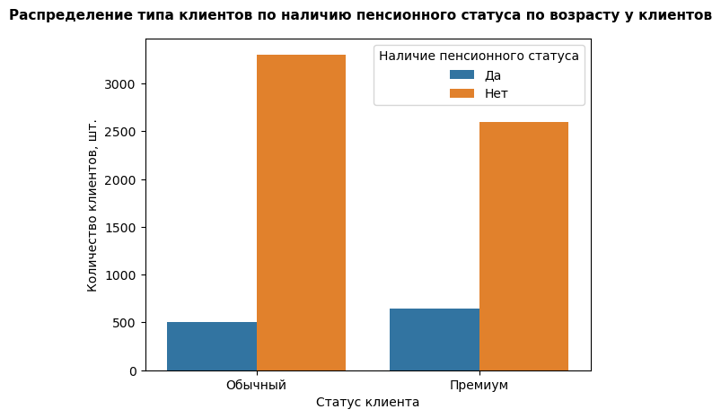

```python
fig = plt.figure()
ax = fig.add_subplot()

fig.suptitle('Распределение типа клиентов по наличию пенсионного статуса по возрасту у клиентов',
             fontsize=11, fontweight='bold', y=0.95)

sns.countplot(x='status_user', hue='senior_citizen', data=total_table, hue_order=['Yes', 'No']);

ax.set(xlabel='Статус клиента', ylabel='Количество клиентов, шт.')
ax.legend(['Да', 'Нет'], title="Наличие пенсионного статуса")

plt.xticks([0, 1], ['Обычный', 'Премиум'])
plt.show();
```

Распределения обычных и премиум клиентов по наличиют пенсионного статуса сопоставимы. В большинстве своем клиенты не обладают пенсионным статусом

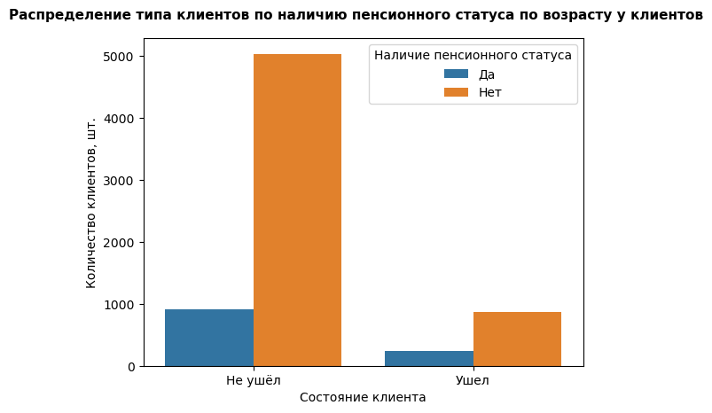

```python
fig = plt.figure()
ax = fig.add_subplot()

fig.suptitle('Распределение типа клиентов по наличию пенсионного статуса по возрасту у клиентов',
             fontsize=11, fontweight='bold', y=0.95)

sns.countplot(x='lost_user', hue='senior_citizen', data=total_table, hue_order=['Yes', 'No']);

ax.set(xlabel='Состояние клиента', ylabel='Количество клиентов, шт.')
ax.legend(['Да', 'Нет'], title="Наличие пенсионного статуса")

plt.xticks([0, 1], ['Не ушёл', 'Ушел'])
plt.show();
```

### Анализ корреляции данных

Столбец *customer_id* является индивидуальным для каждого клиента. Совершенно очевидно, что его не нужно использовать в качестве признака в обучении моделей, т.к. отток клиентов не должен зависить от их индификационных номеров. Поэтому удалим его из датафрейма.

```python
total_table = total_table.drop('customer_id', axis=1)
```

А теперь построим матрицу мультикорреляции:

```
interval columns not set, guessing: ['monthly_charges', 'total_charges', 'lost_user', 'duration', 'number_of_services']
```

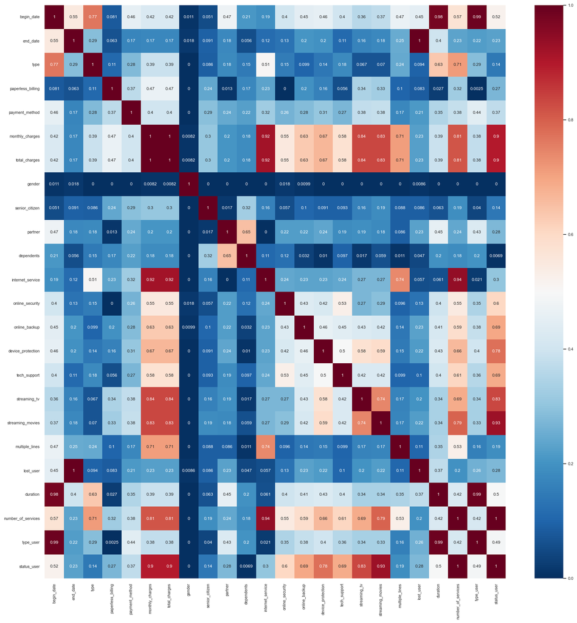

```python
sns.set(font_scale=0.7)
plt.figure(figsize=(20, 20))
sns.heatmap(
    total_table.phik_matrix(),
    cmap='RdBu_r', # задаёт цветовую схему
    annot=True, # рисует значения внутри ячеек
    vmin=0, vmax=1); # указывает начало цветовых кодов от 0 до 1.
```

Также из признаков следует удалить *end_date* и *begin_date* т.к. на основе их был сгенерирован новый признак *duration*. А на основе признака *end_date* была еще сгенерирована его производная - целевой признак, *lost_user*.

### Анализ дисбаланса классов

Проверим баланс классов:

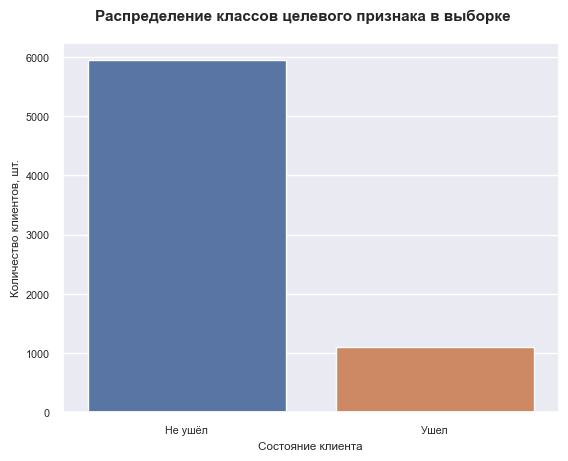

```python
fig = plt.figure()
ax = fig.add_subplot()

fig.suptitle('Распределение классов целевого признака в выборке',
             fontsize=11, fontweight='bold', y=0.95)

sns.countplot(x=total_table['lost_user']);

ax.set(xlabel='Состояние клиента', ylabel='Количество клиентов, шт.')

plt.xticks([0, 1], ['Не ушёл', 'Ушел'])
plt.show();
```

Баланс классов нарушен. При построение моделей, желательно провести балансировку классов.

### Выводы исследовательского анализа

Во время выполнения исследовательского анализа было выполнены следующие шаги:

- на основании значений в поле *end_date* был сгенерирован целевой признак *lost_user*, содержащий значения '1' и '0'. Если значение '1' - клиент отказался от услуг компании, а если '0' - клиент продолжает пользоватся услугами.
- на основании полей *end_date* и *begin_date* было сгенерировано поле *duration*, содержащее продолжительность пользования услугами клиентом.
- Используя столбцы:
  - *internet_service*,
  - *online_security*,
  - *online_backup*,
  - *device_protection*,
  - *tech_support*,
  - *streaming_tv*,
  - *streaming_movies*,
  - *streaming_movies*  
    было создано поле *number_of_services* содержащее количество услуг используемое клинтом.
- Разделили клиентов на типы по продолжительности использования услуг:
  - 'newcomer' - новичок (пользуются услугами не больше года);
  - 'constant' - постоянный (пользуются услугами более года)  
    на основании этого создали новое поле *type_user*.
- Каждому клиенту сопоставим статус, определяемый по количеству используемых услуг:
  - 'ordinary' - обычный (использует до 3 услуг включительно);
  - 'premium' - премиум (использует от 4 услуг).

Отметим особенности выявленные при исследовательском анализе.

**Анализ типов и статусов клиентов показал:**

- Постоянные клиенты, продолжительность оказания услуг которым более 365 дней, преобладают в компании. Также стоит отметить, что чаще компанию покидают тоже постоянные клиенты.
- В компании преобладают обычные клиенты, количество используемых услуг которых ограничивается 3. Стоит отметить, что компанию чаще покидают клиенты премиум, которые используют более 3 услуг.

**Анализ типа оплаты клиентов показал:**

- Клиенты-новички намного чаще используют ежемесячную оплату. Типы оплат постоянных клиентов более сбалансированы между собой.
- Обычные клиенты предпочитаю ежемесячную оплату. У клиентов премиум тип оплаты более сбалансирован.
- У ушедших клиентов типы оплат сбалансированы. Что свидетельствует, о не влияние типа оплаты на решение отказаться от услуг.

**Анализ потраченных средств на услуги по состоянию клинта показал:**

- Среди постоянных клиентов есть такие, которые тратять почти нулевую сумму на оплату услуг. Такие клиенты используют минимум услуг, ограничиваясь лишь телефонией.
- В компании присутствуют премиум клиенты, которые потратили минимальную сумму на оплату услуг. Это клиенты новички.
- Сумма потраченная на оплату, клиентами которые решил отказаться от услуг редка превышает значение 6000.
- Согласно диаграмме размаха для потраченных средств на оплату услуг клиентами датасет скошен вправо. А значения выходящие за примерно 6700 выявлены графиком, как выбросы (исключать эти значения не станем, т.к. это снизит вариативность выборки)
- В среднем постоянные клиенты ежемесячно платят больше, чем клиенты новички.
- Клиенты со статусом премиум в среднем платят ежемесячно больше, чем обычные клиенты.
- Распределения ежемесячной оплаты для отказавшихся и не отказавшихся от услуг клиентов сопоставимы.
- Согласно диаграмме размаха для для ежемесячной оплаты услуг клиентами датасет скошен влево.

**Анализ продолжительности пользования услугами по ушедшим и не ушедшим клиентам показал:**

- Согласно диаграмме размаха продолжительности пользования услугами датасет скошен вправо.
- Премиум клиенты равномерно распределены по продолжительности пользования услугами. Что касается обычных клиентов, то со временем их становится меньше. Это может быть обусловлено с получением ими статуса премиум или отказом от услуг компании.
- Среднее значение продолжительности пользования услугами клиентов которые решили отказаться, составляет 1000 дней.

**Анализ наличие супруги по ушедшим и не ушедшим пользователям показал:**

- Большинство клиентов новичков не имеют супругу. Постоянные клиенты в большинстве своем имеют супругу.
- Обычные клиенты в большинстве своем не имеют супругу, а вот клиенты пермиум на оборот в большинстве имеют супругу.
- В большинстве своем клиенты не отказывающиеся от услуг компании не имеют супругу. А вот клиенты решившие отказаться от услуг в большинстве своем имеют супругу.

**Анализ наличия пенсионного статуса по возрасту у клиентов показал:**

- Распределения клиентов новичков и постоянных по наличиют пенсионного статуса сопоставимы. В большинстве своем клиенты не обладают пенсионным статусом.
- Распределения обычных и премиум клиентов по наличиют пенсионного статуса сопоставимы. В большинстве своем клиенты не обладают пенсионным статусом.
- клиенты имеющие пенсионный возраст реже отказываюстя от услуг компании.

**Анализ корреляции данных показал**, что признаки:

- *gender*,
- *internet_service*,
- *paperless_billing*,
- *senior_citizen*,
- *dependents*

имеют малое значение корреляции с остальными. Данные признаки можно исключить без вреда к качеству обучаемой модели. Но исключать эти признаки пока не будем, сперва проведем обучение и тестирование модели. А уже после проанализируем важность каждого признака и сопоставим выводы с таблицей мультикорреляции.

**Анализ дисбаланса классов показал**, что баланс классов нарушен. Поэтому при построение моделей, желательно провести балансировку классов.

## Подготовка тренировочной и тестовой выборок

```python
RANDOM_STATE = 310723
```

```python
drop_columns = ['lost_user',
                'end_date',
                'begin_date']
features = total_table.drop(drop_columns, axis=1)
target= total_table['lost_user']
```

```python
features_train, features_test, target_train, target_test = train_test_split(
    features, target, test_size=0.25, random_state=RANDOM_STATE, stratify=target)
```

```python
features_train.shape
```

```
(5282, 21)
```

```python
target_train.shape
```

```
(5282,)
```

```python
features_test.shape
```

```
(1761, 21)
```

```python
target_test.shape
```

```
(1761,)
```

```python
encoder = OneHotEncoder(handle_unknown='ignore', drop='first')
```

```python
scaler = StandardScaler()
```

```python
num_cols = ['total_charges', 'duration', 'monthly_charges']
cat_cols = list(features_train.drop(num_cols, axis=1).columns)

cat_cols
```

```
['type',
 'paperless_billing',
 'payment_method',
 'gender',
 'senior_citizen',
 'partner',
 'dependents',
 'internet_service',
 'online_security',
 'online_backup',
 'device_protection',
 'tech_support',
 'streaming_tv',
 'streaming_movies',
 'multiple_lines',
 'number_of_services',
 'type_user',
 'status_user']
```

```python
transformer = ColumnTransformer([('cat_cols', encoder, cat_cols),
                                ('num_cols', scaler, num_cols)])
```

```python
#Функция для проведения обучения модели на кросс-валидации по сетке параметров
#с использованием конвейера на основе pipeline

def make_grid_search(model, param_grid, features_train, target_train):
    pipe = Pipeline([('preprocessing', transformer), ('model', model)])
    grid_search = GridSearchCV(pipe, param_grid=param_grid, cv=5, scoring='roc_auc', verbose=2)

    model_grid = grid_search.fit(features_train, target_train)

    print(f"Лучшие параметры модели:")
    print(grid_search.best_params_)
    print('-'*10)
    print(f"Оценка ROC_AUC модели: {grid_search.best_score_:.3f}")

    return model_grid
```

## Обучение моделей

```python
%%time
model = DecisionTreeClassifier(random_state=RANDOM_STATE, class_weight='balanced')
param_grid={
             'model__max_depth':list(range(1, 15, 4)),
             'model__criterion':['gini', 'entropy']
           }

model_dtc = make_grid_search(model, param_grid, features_train, target_train)
```

```
Fitting 5 folds for each of 8 candidates, totalling 40 fits
[CV] END ..........model__criterion=gini, model__max_depth=1; total time=   0.0s
[CV] END ..........model__criterion=gini, model__max_depth=1; total time=   0.0s
[CV] END ..........model__criterion=gini, model__max_depth=1; total time=   0.0s
[CV] END ..........model__criterion=gini, model__max_depth=1; total time=   0.0s
[CV] END ..........model__criterion=gini, model__max_depth=1; total time=   0.0s
[CV] END ..........model__criterion=gini, model__max_depth=5; total time=   0.0s
[CV] END ..........model__criterion=gini, model__max_depth=5; total time=   0.0s
[CV] END ..........model__criterion=gini, model__max_depth=5; total time=   0.0s
[CV] END ..........model__criterion=gini, model__max_depth=5; total time=   0.0s
[CV] END ..........model__criterion=gini, model__max_depth=5; total time=   0.0s
[CV] END ..........model__criterion=gini, model__max_depth=9; total time=   0.0s
[CV] END ..........model__criterion=gini, model__max_depth=9; total time=   0.0s
[CV] END ..........model__criterion=gini, model__max_depth=9; total time=   0.0s
[CV] END ..........model__criterion=gini, model__max_depth=9; total time=   0.0s
[CV] END ..........model__criterion=gini, model__max_depth=9; total time=   0.0s
[CV] END .........model__criterion=gini, model__max_depth=13; total time=   0.0s
[CV] END .........model__criterion=gini, model__max_depth=13; total time=   0.0s
[CV] END .........model__criterion=gini, model__max_depth=13; total time=   0.0s
[CV] END .........model__criterion=gini, model__max_depth=13; total time=   0.0s
[CV] END .........model__criterion=gini, model__max_depth=13; total time=   0.0s
[CV] END .......model__criterion=entropy, model__max_depth=1; total time=   0.0s
[CV] END .......model__criterion=entropy, model__max_depth=1; total time=   0.0s
[CV] END .......model__criterion=entropy, model__max_depth=1; total time=   0.0s
[CV] END .......model__criterion=entropy, model__max_depth=1; total time=   0.0s
[CV] END .......model__criterion=entropy, model__max_depth=1; total time=   0.0s
[CV] END .......model__criterion=entropy, model__max_depth=5; total time=   0.0s
[CV] END .......model__criterion=entropy, model__max_depth=5; total time=   0.0s
[CV] END .......model__criterion=entropy, model__max_depth=5; total time=   0.0s
[CV] END .......model__criterion=entropy, model__max_depth=5; total time=   0.0s
[CV] END .......model__criterion=entropy, model__max_depth=5; total time=   0.0s
[CV] END .......model__criterion=entropy, model__max_depth=9; total time=   0.0s
[CV] END .......model__criterion=entropy, model__max_depth=9; total time=   0.0s
[CV] END .......model__criterion=entropy, model__max_depth=9; total time=   0.0s
[CV] END .......model__criterion=entropy, model__max_depth=9; total time=   0.0s
[CV] END .......model__criterion=entropy, model__max_depth=9; total time=   0.0s
[CV] END ......model__criterion=entropy, model__max_depth=13; total time=   0.0s
[CV] END ......model__criterion=entropy, model__max_depth=13; total time=   0.0s
[CV] END ......model__criterion=entropy, model__max_depth=13; total time=   0.0s
[CV] END ......model__criterion=entropy, model__max_depth=13; total time=   0.0s
[CV] END ......model__criterion=entropy, model__max_depth=13; total time=   0.0s
Лучшие параметры модели:
{'model__criterion': 'gini', 'model__max_depth': 5}
----------
Оценка ROC_AUC модели: 0.777
CPU times: total: 2.52 s
Wall time: 2.88 s
```

```python
%%time
model = RandomForestClassifier(random_state=RANDOM_STATE, class_weight='balanced')
param_grid={
              'model__max_depth':list(range(1, 15, 4)),
              'model__n_estimators':list(range(1, 11, 3))
           }

model_rfc = make_grid_search(model, param_grid, features_train, target_train)
```

```
Fitting 5 folds for each of 16 candidates, totalling 80 fits
[CV] END ..........model__max_depth=1, model__n_estimators=1; total time=   0.0s
[CV] END ..........model__max_depth=1, model__n_estimators=1; total time=   0.0s
[CV] END ..........model__max_depth=1, model__n_estimators=1; total time=   0.0s
[CV] END ..........model__max_depth=1, model__n_estimators=1; total time=   0.0s
[CV] END ..........model__max_depth=1, model__n_estimators=1; total time=   0.0s
[CV] END ..........model__max_depth=1, model__n_estimators=4; total time=   0.0s
[CV] END ..........model__max_depth=1, model__n_estimators=4; total time=   0.0s
[CV] END ..........model__max_depth=1, model__n_estimators=4; total time=   0.0s
[CV] END ..........model__max_depth=1, model__n_estimators=4; total time=   0.0s
[CV] END ..........model__max_depth=1, model__n_estimators=4; total time=   0.0s
[CV] END ..........model__max_depth=1, model__n_estimators=7; total time=   0.0s
[CV] END ..........model__max_depth=1, model__n_estimators=7; total time=   0.0s
[CV] END ..........model__max_depth=1, model__n_estimators=7; total time=   0.0s
[CV] END ..........model__max_depth=1, model__n_estimators=7; total time=   0.0s
[CV] END ..........model__max_depth=1, model__n_estimators=7; total time=   0.0s
[CV] END .........model__max_depth=1, model__n_estimators=10; total time=   0.0s
[CV] END .........model__max_depth=1, model__n_estimators=10; total time=   0.0s
[CV] END .........model__max_depth=1, model__n_estimators=10; total time=   0.0s
[CV] END .........model__max_depth=1, model__n_estimators=10; total time=   0.0s
[CV] END .........model__max_depth=1, model__n_estimators=10; total time=   0.0s
[CV] END ..........model__max_depth=5, model__n_estimators=1; total time=   0.0s
[CV] END ..........model__max_depth=5, model__n_estimators=1; total time=   0.0s
[CV] END ..........model__max_depth=5, model__n_estimators=1; total time=   0.0s
[CV] END ..........model__max_depth=5, model__n_estimators=1; total time=   0.0s
[CV] END ..........model__max_depth=5, model__n_estimators=1; total time=   0.0s
[CV] END ..........model__max_depth=5, model__n_estimators=4; total time=   0.0s
[CV] END ..........model__max_depth=5, model__n_estimators=4; total time=   0.0s
[CV] END ..........model__max_depth=5, model__n_estimators=4; total time=   0.0s
[CV] END ..........model__max_depth=5, model__n_estimators=4; total time=   0.0s
[CV] END ..........model__max_depth=5, model__n_estimators=4; total time=   0.0s
[CV] END ..........model__max_depth=5, model__n_estimators=7; total time=   0.0s
[CV] END ..........model__max_depth=5, model__n_estimators=7; total time=   0.0s
[CV] END ..........model__max_depth=5, model__n_estimators=7; total time=   0.0s
[CV] END ..........model__max_depth=5, model__n_estimators=7; total time=   0.0s
[CV] END ..........model__max_depth=5, model__n_estimators=7; total time=   0.0s
[CV] END .........model__max_depth=5, model__n_estimators=10; total time=   0.0s
[CV] END .........model__max_depth=5, model__n_estimators=10; total time=   0.0s
[CV] END .........model__max_depth=5, model__n_estimators=10; total time=   0.0s
[CV] END .........model__max_depth=5, model__n_estimators=10; total time=   0.0s
```

[output cut: 32 more lines]

```
[CV] END .........model__max_depth=13, model__n_estimators=7; total time=   0.0s
[CV] END .........model__max_depth=13, model__n_estimators=7; total time=   0.0s
[CV] END .........model__max_depth=13, model__n_estimators=7; total time=   0.0s
[CV] END .........model__max_depth=13, model__n_estimators=7; total time=   0.0s
[CV] END ........model__max_depth=13, model__n_estimators=10; total time=   0.0s
[CV] END ........model__max_depth=13, model__n_estimators=10; total time=   0.0s
[CV] END ........model__max_depth=13, model__n_estimators=10; total time=   0.0s
[CV] END ........model__max_depth=13, model__n_estimators=10; total time=   0.0s
[CV] END ........model__max_depth=13, model__n_estimators=10; total time=   0.0s
Лучшие параметры модели:
{'model__max_depth': 9, 'model__n_estimators': 10}
----------
Оценка ROC_AUC модели: 0.796
CPU times: total: 5.67 s
Wall time: 6.3 s
```

```python
%%time
model = CatBoostClassifier(loss_function="Logloss", iterations=100, random_state=RANDOM_STATE, verbose=0)
param_grid={
              'model__depth':list(range(1, 15, 4)),
              'model__learning_rate':list([x/10 for x in range(1, 11, 4)])
           }

model_cbc = make_grid_search(model, param_grid, features_train, target_train)
```

```
Fitting 5 folds for each of 12 candidates, totalling 60 fits
[CV] END ...........model__depth=1, model__learning_rate=0.1; total time=   1.4s
[CV] END ...........model__depth=1, model__learning_rate=0.1; total time=   0.1s
[CV] END ...........model__depth=1, model__learning_rate=0.1; total time=   0.4s
[CV] END ...........model__depth=1, model__learning_rate=0.1; total time=   0.3s
[CV] END ...........model__depth=1, model__learning_rate=0.1; total time=   0.2s
[CV] END ...........model__depth=1, model__learning_rate=0.5; total time=   0.2s
[CV] END ...........model__depth=1, model__learning_rate=0.5; total time=   0.2s
[CV] END ...........model__depth=1, model__learning_rate=0.5; total time=   0.2s
[CV] END ...........model__depth=1, model__learning_rate=0.5; total time=   0.2s
[CV] END ...........model__depth=1, model__learning_rate=0.5; total time=   0.2s
[CV] END ...........model__depth=1, model__learning_rate=0.9; total time=   0.2s
[CV] END ...........model__depth=1, model__learning_rate=0.9; total time=   0.4s
[CV] END ...........model__depth=1, model__learning_rate=0.9; total time=   0.2s
[CV] END ...........model__depth=1, model__learning_rate=0.9; total time=   0.3s
[CV] END ...........model__depth=1, model__learning_rate=0.9; total time=   0.2s
[CV] END ...........model__depth=5, model__learning_rate=0.1; total time=   0.4s
[CV] END ...........model__depth=5, model__learning_rate=0.1; total time=   0.4s
[CV] END ...........model__depth=5, model__learning_rate=0.1; total time=   0.4s
[CV] END ...........model__depth=5, model__learning_rate=0.1; total time=   0.4s
[CV] END ...........model__depth=5, model__learning_rate=0.1; total time=   0.5s
[CV] END ...........model__depth=5, model__learning_rate=0.5; total time=   0.4s
[CV] END ...........model__depth=5, model__learning_rate=0.5; total time=   0.4s
[CV] END ...........model__depth=5, model__learning_rate=0.5; total time=   0.4s
[CV] END ...........model__depth=5, model__learning_rate=0.5; total time=   0.4s
[CV] END ...........model__depth=5, model__learning_rate=0.5; total time=   0.4s
[CV] END ...........model__depth=5, model__learning_rate=0.9; total time=   0.4s
[CV] END ...........model__depth=5, model__learning_rate=0.9; total time=   0.4s
[CV] END ...........model__depth=5, model__learning_rate=0.9; total time=   0.4s
[CV] END ...........model__depth=5, model__learning_rate=0.9; total time=   0.4s
[CV] END ...........model__depth=5, model__learning_rate=0.9; total time=   0.4s
[CV] END ...........model__depth=9, model__learning_rate=0.1; total time=   2.2s
[CV] END ...........model__depth=9, model__learning_rate=0.1; total time=   2.3s
[CV] END ...........model__depth=9, model__learning_rate=0.1; total time=   2.1s
[CV] END ...........model__depth=9, model__learning_rate=0.1; total time=   2.6s
[CV] END ...........model__depth=9, model__learning_rate=0.1; total time=   2.2s
[CV] END ...........model__depth=9, model__learning_rate=0.5; total time=   2.1s
[CV] END ...........model__depth=9, model__learning_rate=0.5; total time=   2.4s
[CV] END ...........model__depth=9, model__learning_rate=0.5; total time=   2.2s
[CV] END ...........model__depth=9, model__learning_rate=0.5; total time=   2.1s
```

[output cut: 12 more lines]

```
[CV] END ..........model__depth=13, model__learning_rate=0.5; total time=  41.1s
[CV] END ..........model__depth=13, model__learning_rate=0.5; total time=  39.3s
[CV] END ..........model__depth=13, model__learning_rate=0.5; total time=  38.7s
[CV] END ..........model__depth=13, model__learning_rate=0.5; total time=  36.8s
[CV] END ..........model__depth=13, model__learning_rate=0.9; total time=  36.2s
[CV] END ..........model__depth=13, model__learning_rate=0.9; total time=  33.8s
[CV] END ..........model__depth=13, model__learning_rate=0.9; total time=  32.8s
[CV] END ..........model__depth=13, model__learning_rate=0.9; total time=  32.7s
[CV] END ..........model__depth=13, model__learning_rate=0.9; total time=  33.0s
Лучшие параметры модели:
{'model__depth': 5, 'model__learning_rate': 0.5}
----------
Оценка ROC_AUC модели: 0.903
CPU times: total: 8min 36s
Wall time: 9min 27s
```

### Выводы по обучению моделей

Были обучены три модели:

- решающее дерево (DecisionTreeClassifier);
- случайный лес (RandomForestClassifier);
- градиентный бустинг (CatBoostClassifier).

Результаты обучения моделей приведены в таблице:

| Модель | Время обучения | Качество модели (ROC AUC) |
| --- | --- | --- |
| DecisionTreeClassifier | 2.52 с | 0.777 |
| RandomForestClassifier | 5.67 с | 0.796 |
| CatBoostClassifier | 8 мин. 36 с | 0.903 |

Опираясь на критерии заказчика (ROC AUC не ниже 0.85), рекомендуемой к использованию модели является CatBoostClassifier, т.к. данная модель имеет наилучшее качестко метрики ROC AUC на кросс-валидации. Теперь перейдем к тестированию модели.

## Тестирование модели

```python
predictions_test = model_cbc.predict_proba(features_test)
probabilities_one_test = predictions_test[:, 1]
print("AUC-ROC:", roc_auc_score(target_test, probabilities_one_test))
```

```
AUC-ROC: 0.9036669521595498
```

При тестировании модель показала значение метрики ROC AUC равной 0.9037, требования заказчика было значение метрики не ниже 0.85. Т.о. модель можно применять для предсказания оттока клиентов.

Построим график ROC-кривой

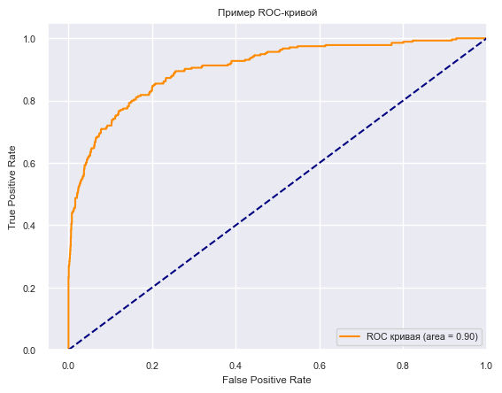

```python
fpr, tpr, treshold = roc_curve(target_test, probabilities_one_test)
roc_auc = auc(fpr, tpr)
# строим график
plt.plot(fpr, tpr, color='darkorange',
         label='ROC кривая (area = %0.2f)' % roc_auc)
plt.plot([0, 1], [0, 1], color='navy', linestyle='--')
plt.xlim([-0.05, 1.0])
plt.ylim([0.0, 1.05])
plt.xlabel('False Positive Rate')
plt.ylabel('True Positive Rate')
plt.title('Пример ROC-кривой')
plt.legend(loc="lower right")
plt.show()
```

Посмотрим на значимость признаков для модели.

```python
feature_importance = model_cbc.best_estimator_.named_steps["model"].feature_importances_
```

```python
feature_names = model_cbc.best_estimator_.named_steps["preprocessing"].get_feature_names_out()
```

```python
data_feature_importance = pd.DataFrame({'feature_names': feature_names, 'feature_importance': feature_importance})
data_feature_importance
```

|  | feature_names | feature_importance |
| --- | --- | --- |
| 0 | cat_cols__type_One year | 2.159771 |
| 1 | cat_cols__type_Two year | 3.646601 |
| 2 | cat_cols__paperless_billing_Yes | 0.996472 |
| 3 | cat_cols__payment_method_Credit card (automatic) | 0.965510 |
| 4 | cat_cols__payment_method_Electronic check | 1.439186 |
| 5 | cat_cols__payment_method_Mailed check | 1.957633 |
| 6 | cat_cols__gender_Male | 0.652072 |
| 7 | cat_cols__senior_citizen_Yes | 1.336431 |
| 8 | cat_cols__partner_Yes | 3.985196 |
| 9 | cat_cols__dependents_Yes | 2.240681 |
| 10 | cat_cols__internet_service_Fiber optic | 0.196204 |
| 11 | cat_cols__internet_service_No internet | 0.000000 |
| 12 | cat_cols__online_security_Yes | 1.097051 |
| 13 | cat_cols__online_backup_Yes | 2.482803 |
| 14 | cat_cols__device_protection_Yes | 1.104811 |
| 15 | cat_cols__tech_support_Yes | 1.176157 |
| 16 | cat_cols__streaming_tv_Yes | 0.185617 |
| 17 | cat_cols__streaming_movies_Yes | 0.623171 |
| 18 | cat_cols__multiple_lines_No phone | 0.976867 |
| 19 | cat_cols__multiple_lines_Yes | 2.477629 |
| 20 | cat_cols__number_of_services_1 | 0.125866 |
| 21 | cat_cols__number_of_services_2 | 1.027896 |
| 22 | cat_cols__number_of_services_3 | 0.421692 |
| 23 | cat_cols__number_of_services_4 | 0.825189 |
| 24 | cat_cols__number_of_services_5 | 0.931551 |
| 25 | cat_cols__number_of_services_6 | 0.691874 |
| 26 | cat_cols__number_of_services_7 | 0.505965 |
| 27 | cat_cols__number_of_services_8 | 0.000000 |
| 28 | cat_cols__type_user_newcomer | 0.344781 |
| 29 | cat_cols__status_user_premium | 0.000000 |
| 30 | num_cols__total_charges | 5.378902 |
| 31 | num_cols__duration | 54.632351 |
| 32 | num_cols__monthly_charges | 5.414070 |

```python
data_feature_importance = (data_feature_importance.replace(
    {
        'cat_cols__type_One year': 'type_one_year',
        'cat_cols__type_Two year': 'type_two_year',
        'cat_cols__paperless_billing_Yes': 'paperless_billing',
        'cat_cols__payment_method_Credit card (automatic)': 'payment_method_credit_card',
        'cat_cols__payment_method_Electronic check': 'method_electronic_check',
        'cat_cols__payment_method_Mailed check': 'payment_method_mailed_check',
        'cat_cols__gender_Male': 'gender_male',
        'cat_cols__senior_citizen_Yes': 'senior_citizen',
        'cat_cols__partner_Yes': 'partner',
        'cat_cols__dependents_Yes': 'dependents',
        'cat_cols__internet_service_Fiber optic': 'internet_service_fiber_optic',
        'cat_cols__internet_service_No internet': 'internet_service_no_internet',
        'cat_cols__online_security_Yes': 'online_security',
        'cat_cols__online_backup_Yes': 'online_backup',
        'cat_cols__device_protection_Yes': 'device_protection',
        'cat_cols__tech_support_Yes': 'tech_support',
        'cat_cols__streaming_tv_Yes': 'streaming_tv',
        'cat_cols__streaming_movies_Yes': 'streaming_movies',
        'cat_cols__multiple_lines_Yes': 'multiple_lines',
        'cat_cols__number_of_services_1': 'number_of_services_1',
        'cat_cols__number_of_services_2': 'number_of_services_2',
        'cat_cols__number_of_services_3': 'number_of_services_3',
        'cat_cols__number_of_services_4': 'number_of_services_4',
        'cat_cols__number_of_services_5': 'number_of_services_5',
        'cat_cols__number_of_services_6': 'number_of_services_6',
        'cat_cols__number_of_services_7': 'number_of_services_7',
        'cat_cols__number_of_services_8': 'number_of_services_8',
        'cat_cols__type_user_newcomer': 'type_user',
        'cat_cols__status_user_premium': 'status_user',
        'num_cols__total_charges': 'total_charges',
        'num_cols__duration': 'duration',
        'num_cols__monthly_charges': 'monthly_charges'
    })
)
```

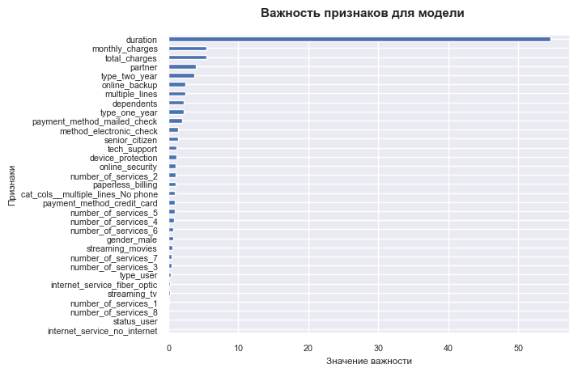

```python
fig = plt.figure()
ax = fig.add_subplot()

fig.suptitle('Важность признаков для модели',
             fontsize=11, fontweight='bold', y=0.95)


data_feature_importance.sort_values(
    by=['feature_importance'],
    ascending=True).plot.barh(x='feature_names', y='feature_importance', ax=ax, legend=False);

ax.set(xlabel='Значение важности', ylabel='Признаки')

plt.show();
```

Анализируя график важности признаков модели, отметим топ 10 самых важных:

- duration - продолжительность пользования услугами;
- total_charges - сумма потраченная на оплату услуг;
- monthly_charges - ежемесячные траты на услуги;
- type_two_year - тип оплаты раз в два года;
- partner - наличие супруга(и);
- type_one_year - тип оплаты раз в год;
- online_backup - Использование услуги облачное хранилище файлов для резервного копирования данных;
- payment_method_mailed_check - способ оплаты чеком через эмейл;
- multiple_lines - наличие возможности ведения параллельных линий во время звонка;
- dependents - наличие иждивенцев.

  Менее важные признаки можно отбросить, тем самым улучшить модель.

Обучим модель на полном наборе данных - тренировочная выборка плюс тестовая выборка:

```python
%%time
model = CatBoostClassifier(loss_function="Logloss", iterations=100, random_state=RANDOM_STATE, verbose=0)
param_grid={
              'model__depth':list(range(1, 15, 4)),
              'model__learning_rate':list([x/10 for x in range(1, 11, 4)])
           }

model_cbc = make_grid_search(model, param_grid, features, target)
```

```
Fitting 5 folds for each of 12 candidates, totalling 60 fits
[CV] END ...........model__depth=1, model__learning_rate=0.1; total time=   0.2s
[CV] END ...........model__depth=1, model__learning_rate=0.1; total time=   0.2s
[CV] END ...........model__depth=1, model__learning_rate=0.1; total time=   0.2s
[CV] END ...........model__depth=1, model__learning_rate=0.1; total time=   0.2s
[CV] END ...........model__depth=1, model__learning_rate=0.1; total time=   0.2s
[CV] END ...........model__depth=1, model__learning_rate=0.5; total time=   0.2s
[CV] END ...........model__depth=1, model__learning_rate=0.5; total time=   0.4s
[CV] END ...........model__depth=1, model__learning_rate=0.5; total time=   0.3s
[CV] END ...........model__depth=1, model__learning_rate=0.5; total time=   0.2s
[CV] END ...........model__depth=1, model__learning_rate=0.5; total time=   0.2s
[CV] END ...........model__depth=1, model__learning_rate=0.9; total time=   0.2s
[CV] END ...........model__depth=1, model__learning_rate=0.9; total time=   0.3s
[CV] END ...........model__depth=1, model__learning_rate=0.9; total time=   0.3s
[CV] END ...........model__depth=1, model__learning_rate=0.9; total time=   0.2s
[CV] END ...........model__depth=1, model__learning_rate=0.9; total time=   0.2s
[CV] END ...........model__depth=5, model__learning_rate=0.1; total time=   0.4s
[CV] END ...........model__depth=5, model__learning_rate=0.1; total time=   0.6s
[CV] END ...........model__depth=5, model__learning_rate=0.1; total time=   0.5s
[CV] END ...........model__depth=5, model__learning_rate=0.1; total time=   0.4s
[CV] END ...........model__depth=5, model__learning_rate=0.1; total time=   0.6s
[CV] END ...........model__depth=5, model__learning_rate=0.5; total time=   0.4s
[CV] END ...........model__depth=5, model__learning_rate=0.5; total time=   0.5s
[CV] END ...........model__depth=5, model__learning_rate=0.5; total time=   0.4s
[CV] END ...........model__depth=5, model__learning_rate=0.5; total time=   0.6s
[CV] END ...........model__depth=5, model__learning_rate=0.5; total time=   0.5s
[CV] END ...........model__depth=5, model__learning_rate=0.9; total time=   0.5s
[CV] END ...........model__depth=5, model__learning_rate=0.9; total time=   0.5s
[CV] END ...........model__depth=5, model__learning_rate=0.9; total time=   0.4s
[CV] END ...........model__depth=5, model__learning_rate=0.9; total time=   0.4s
[CV] END ...........model__depth=5, model__learning_rate=0.9; total time=   0.6s
[CV] END ...........model__depth=9, model__learning_rate=0.1; total time=   2.4s
[CV] END ...........model__depth=9, model__learning_rate=0.1; total time=   2.3s
[CV] END ...........model__depth=9, model__learning_rate=0.1; total time=   2.2s
[CV] END ...........model__depth=9, model__learning_rate=0.1; total time=   2.3s
[CV] END ...........model__depth=9, model__learning_rate=0.1; total time=   2.2s
[CV] END ...........model__depth=9, model__learning_rate=0.5; total time=   2.5s
[CV] END ...........model__depth=9, model__learning_rate=0.5; total time=   2.3s
[CV] END ...........model__depth=9, model__learning_rate=0.5; total time=   2.3s
[CV] END ...........model__depth=9, model__learning_rate=0.5; total time=   2.3s
```

[output cut: 12 more lines]

```
[CV] END ..........model__depth=13, model__learning_rate=0.5; total time=  35.3s
[CV] END ..........model__depth=13, model__learning_rate=0.5; total time=  34.1s
[CV] END ..........model__depth=13, model__learning_rate=0.5; total time=  32.1s
[CV] END ..........model__depth=13, model__learning_rate=0.5; total time=  33.0s
[CV] END ..........model__depth=13, model__learning_rate=0.9; total time=  35.3s
[CV] END ..........model__depth=13, model__learning_rate=0.9; total time=  33.4s
[CV] END ..........model__depth=13, model__learning_rate=0.9; total time=  35.4s
[CV] END ..........model__depth=13, model__learning_rate=0.9; total time=  35.0s
[CV] END ..........model__depth=13, model__learning_rate=0.9; total time=  35.8s
Лучшие параметры модели:
{'model__depth': 5, 'model__learning_rate': 0.5}
----------
Оценка ROC_AUC модели: 0.917
CPU times: total: 8min 50s
Wall time: 9min 29s
```

## Выводы

Отметим особенности выполнения проекта.

При **обзоре данных** пропуски и полные дубликаты в датафреймах не обнаружены.

В процессе **предобработки данных** были выполнены следующие операции:

- привели названия признаков к стилю python.
- заменили значение "No" в таблице *end_date* на дату выгрузки данных из БД. Это позволило в дальнейшем сгенерировать новый признак - продолжительность оказания услуг клиентам.
- изменили тип данных у полей *begin_date* и *end_date* на datetime.
- изменили тип данных у поля *total_charges* на числовой.
- обработали пропуски поля *total_charges*, исключив их. Пропуски возникли по причине того, что клиенты пришли в компанию в дату выгрузки данных, и соответствующее значение в поле *total_charges* отсутствовало.
- убедились в отсутствие полных дубликатов в таблицах.
- привели к общему виду (Yes/No) значения столбца senior_citizen таблцицы personal.
- объединили таблицы в общую таблицу *total_table*. Использовался методом *merge*. Объединение проводилось по полю *customer_id*, способом *left*. Объединяли начиная с таблицы *contract*.
- после объединения выполнялась обработка пропусков:
  - в столбце *internet_service* пропуски были заменены на 'No internet';
  - в столбце *online_security* пропуски были заменены на 'No';
  - в столбце *online_backup* пропуски были заменены на 'No';
  - в столбце *device_protection* пропуски были заменены на 'No';
  - в столбце *tech_support* пропуски были заменены на 'No';
  - в столбце *streaming_tv* пропуски были заменены на 'No';
  - в столбце *streaming_movies* пропуски были заменены на 'No';
  - в столбце *multiple_lines* пропуски были заменены на 'No phone'.

Во время выполнения **исследовательского анализа** было выполнены следующие шаги:

- на основании значений в поле *end_date* был сгенерирован целевой признак *lost_user*, содержащий значения '1' и '0'. Если значение '1' - клиент отказался от услуг компании, а если '0' - клиент продолжает пользоватся услугами.
- на основании полей *end_date* и *begin_date* было сгенерировано поле *duration*, содержащее продолжительность пользования услугами клиентом.
- Используя столбцы:
  - *internet_service*,
  - *online_security*,
  - *online_backup*,
  - *device_protection*,
  - *tech_support*,
  - *streaming_tv*,
  - *streaming_movies*,
  - *streaming_movies*  
    было создано поле *number_of_services* содержащее количество услуг используемое клинтом.
- Разделили клиентов на типы по продолжительности использования услуг:
  - 'newcomer' - новичок (пользуются услугами не больше года);
  - 'constant' - постоянный (пользуются услугами более года)  
    на основании этого создали новое поле *type_user*.
- Каждому клиенту сопоставим статус, определяемый по количеству используемых услуг:
  - 'ordinary' - обычный (использует до 3 услуг включительно);
  - 'premium' - премиум (использует от 4 услуг).

Отметим особенности выявленные при исследовательском анализе.

**Анализ типов и статусов клиентов показал:**

- Постоянные клиенты, продолжительность оказания услуг которым более 365 дней, преобладают в компании. Также стоит отметить, что чаще компанию покидают тоже постоянные клиенты.
- В компании преобладают обычные клиенты, количество используемых услуг которых ограничивается 3. Стоит отметить, что компанию чаще покидают клиенты премиум, которые используют более 3 услуг.

**Анализ типа оплаты клиентов показал:**

- Клиенты-новички намного чаще используют ежемесячную оплату. Типы оплат постоянных клиентов более сбалансированы между собой.
- Обычные клиенты предпочитаю ежемесячную оплату. У клиентов премиум тип оплаты более сбалансирован.
- У ушедших клиентов типы оплат сбалансированы. Что свидетельствует, о не влияние типа оплаты на решение отказаться от услуг.

**Анализ потраченных средств на услуги по состоянию клинта показал:**

- Среди постоянных клиентов есть такие, которые тратять почти нулевую сумму на оплату услуг. Такие клиенты используют минимум услуг, ограничиваясь лишь телефонией.
- В компании присутствуют премиум клиенты, которые потратили минимальную сумму на оплату услуг. Это клиенты новички.
- Сумма потраченная на оплату, клиентами которые решил отказаться от услуг редка превышает значение 6000.
- Согласно диаграмме размаха для потраченных средств на оплату услуг клиентами датасет скошен вправо. А значения выходящие за примерно 6700 выявлены графиком, как выбросы (исключать эти значения не станем, т.к. это снизит вариативность выборки)
- В среднем постоянные клиенты ежемесячно платят больше, чем клиенты новички.
- Клиенты со статусом премиум в среднем платят ежемесячно больше, чем обычные клиенты.
- Распределения ежемесячной оплаты для отказавшихся и не отказавшихся от услуг клиентов сопоставимы.
- Согласно диаграмме размаха для для ежемесячной оплаты услуг клиентами датасет скошен влево.

**Анализ продолжительности пользования услугами по ушедшим и не ушедшим клиентам показал:**

- Согласно диаграмме размаха продолжительности пользования услугами датасет скошен вправо.
- Премиум клиенты равномерно распределены по продолжительности пользования услугами. Что касается обычных клиентов, то со временем их становится меньше. Это может быть обусловлено с получением ими статуса премиум или отказом от услуг компании.
- Среднее значение продолжительности пользования услугами клиентов которые решили отказаться, составляет 1000 дней.

**Анализ наличие супруги по ушедшим и не ушедшим пользователям показал:**

- Большинство клиентов новичков не имеют супругу. Постоянные клиенты в большинстве своем имеют супругу.
- Обычные клиенты в большинстве своем не имеют супругу, а вот клиенты пермиум на оборот в большинстве имеют супругу.
- В большинстве своем клиенты не отказывающиеся от услуг компании не имеют супругу. А вот клиенты решившие отказаться от услуг в большинстве своем имеют супругу.

**Анализ наличия пенсионного статуса по возрасту у клиентов показал:**

- Распределения клиентов новичков и постоянных по наличиют пенсионного статуса сопоставимы. В большинстве своем клиенты не обладают пенсионным статусом.
- Распределения обычных и премиум клиентов по наличиют пенсионного статуса сопоставимы. В большинстве своем клиенты не обладают пенсионным статусом.
- клиенты имеющие пенсионный возраст реже отказываюстя от услуг компании.

**Анализ корреляции данных показал**, что признаки:

- *gender*,
- *internet_service*,
- *paperless_billing*,
- *senior_citizen*,
- *dependents*

имеют малое значение корреляции с остальными. Данные признаки можно исключить без вреда к качеству обучаемой модели. Но исключать эти признаки пока не будем, сперва проведем обучение и тестирование модели. А уже после проанализируем важность каждого признака и сопоставим выводы с таблицей мультикорреляции.

**Анализ дисбаланса классов показал**, что баланс классов нарушен. Поэтому при построение моделей, желательно провести балансировку классов.

Были обучены три модели:

- решающее дерево (DecisionTreeClassifier);
- случайный лес (RandomForestClassifier);
- градиентный бустинг (CatBoostClassifier).

Результаты обучения моделей приведены в таблице:

| Модель | Время обучения | Качество модели (ROC AUC) |
| --- | --- | --- |
| DecisionTreeClassifier | 2.52 с | 0.777 |
| RandomForestClassifier | 5.67 с | 0.796 |
| CatBoostClassifier | 8 мин. 36 с | 0.903 |

Опираясь на критерии заказчика (ROC AUC не ниже 0.85), рекомендуемой к использованию модели является CatBoostClassifier, т.к. данная модель имеет наилучшее качестко метрики ROC AUC на кросс-валидации.

При тестировании модель показала значение метрики ROC AUC равной 0.9037, требования заказчика было значение метрики не ниже 0.85. Т.о. модель можно применять для предсказания оттока клиентов.

Анализируя график важности признаков модели, отметили топ 10 самых важных:

- duration - продолжительность пользования услугами;
- total_charges - сумма потраченная на оплату услуг;
- monthly_charges - ежемесячные траты на услуги;
- type_two_year - тип оплаты раз в два года;
- partner - наличие супруга(и);
- type_one_year - тип оплаты раз в год;
- online_backup - Использование услуги облачное хранилище файлов для резервного копирования данных;
- payment_method_mailed_check - способ оплаты чеком через эмейл;
- multiple_lines - наличие возможности ведения параллельных линий во время звонка;
- dependents - наличие иждивенцев.

  Менее важные признаки можно отбросить, тем самым улучшить модель.

В конце работы выбранная модель была обучена на полном наборе данных. При этом метрика ROC AUC составила 0.917.